# Lesson 3B: Importing Data Frame

DS 01-101: In-Depth Introduction to Data Science (Spring 2026)

Author

Affiliation

Hung Tong

Rowan University

## Readings

From **R Coding Basics: An Introduction to the Basics of Coding in R** by Dr. Gaston Sanchez:

- [Import Data Tables](https://www.gastonsanchez.com/R-coding-basics/6-02-import-tables.html)

## Topics

- Built-in data sets
- Importing data
- Inspecting a data frame
- Storing data and objects

## Built-in data frames

R has many built-in data sets:

- `faithful` Old Faithful Gayser Data

```r
?faithful

head(faithful)

#   eruptions waiting
# 1     3.600      79
# 2     1.800      54
# 3     3.333      74
# 4     2.283      62
# 5     4.533      85
# 6     2.883      55
```

- `iris` Edgar Anderson’s Iris Data

```r
?iris

head(iris)

#   Sepal.Length Sepal.Width Petal.Length Petal.Width Species
# 1          5.1         3.5          1.4         0.2  setosa
# 2          4.9         3.0          1.4         0.2  setosa
# 3          4.7         3.2          1.3         0.2  setosa
# 4          4.6         3.1          1.5         0.2  setosa
# 5          5.0         3.6          1.4         0.2  setosa
# 6          5.4         3.9          1.7         0.4  setosa
```

- `mtcars` Motor Trend Car Road Tests

```r
?mtcars

head(mtcars)

#                    mpg cyl disp  hp drat    wt  qsec vs am gear carb
# Mazda RX4         21.0   6  160 110 3.90 2.620 16.46  0  1    4    4
# Mazda RX4 Wag     21.0   6  160 110 3.90 2.875 17.02  0  1    4    4
# Datsun 710        22.8   4  108  93 3.85 2.320 18.61  1  1    4    1
# Hornet 4 Drive    21.4   6  258 110 3.08 3.215 19.44  1  0    3    1
# Hornet Sportabout 18.7   8  360 175 3.15 3.440 17.02  0  0    3    2
# Valiant           18.1   6  225 105 2.76 3.460 20.22  1  0    3    1
```

- `USArrests` Violent Crime Rates by US State

```r
?USArrests

head(USArrests)

#            Murder Assault UrbanPop Rape
# Alabama      13.2     236       58 21.2
# Alaska       10.0     263       48 44.5
# Arizona       8.1     294       80 31.0
# Arkansas      8.8     190       50 19.5
# California    9.0     276       91 40.6
# Colorado      7.9     204       78 38.7
```

## Reading data from the clipboard

A data frame can be made by reading from the clipboard as follows:

- Select and copy the content from a data file

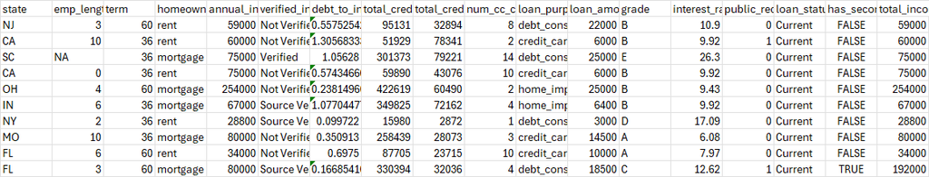

- Use the `read.delim()` function

```r
read.delim('clipboard')
```

## Importing data with `read.table()` and `read.csv()`

- Small and medium-size data sets are usually stored in a **text file** `.txt`
- Data in a text file are separated by a **delimiter** such as white space, comma, tab, or semi-colon.
- A text file in which data are separated by a comma is equivalent to a **comma-separated value** file `.csv`, which is commonly used in statistics and data science due to portability.

```r
### comma-separated value

floor,bed,lease,pool,rent
first,0,9,yes,1200
second,1,12,no,1550
first,2,12,yes,1900
second,1,9,no,1650
first,0,12,yes,1300
```

- The `read.table()` function is a general function to read data from a text file. Before using the function, it is best to move the text file under the current working directory.

```r
read.table('file_name.csv', header = TRUE, sep = ' ')

read.table('file_name.csv', header = TRUE, sep = ',')

read.table('file_name.csv', header = TRUE, sep = '\t')

read.table('file_name.csv', header = TRUE, sep = ';')
```

- The `read.csv()` function is just a wrapper of the `read.table()` function for importing comma-separated value file `.csv`

```r
read.csv('file_name.csv')    # same as read.table('file_name.csv', sep = ',')
```

**Hands-On**

Import the apartment data.

**Answer:**

```r
### R code here
```

## Inspecting a data frame

Given a data frame,

- `str()` shows its overall structure
- `head()` returns its first few rows
- `tail()` returns its last few rows
- `summary()` shows descriptive statistics for its columns
- `dim()` returns a vector dimensions
- `nrow()` returns its number of rows
- `ncol()` returns its number of columns
- `colnames()` and `names()` returns its column names
- `rownames()` returns its row names
- `complete.cases()` returns a logical vector indicating which observations have no missing values.

**Hands-On**

Import and inspect the `iris` data.

**Answer:**

```r
### R code here
```

**Hands-On**

Import and inspect the `loan50` data.

This data set represents 50 loans made through the Lending Club platform, which is a platform that allows individuals to lend to other individuals. Of course, not all loans are created equal. Someone who is a essentially a sure bet to pay back a loan will have an easier time getting a loan with a low interest rate than someone who appears to be riskier. And for people who are very risky? They may not even get a loan offer, or they may not have accepted the loan offer due to a high interest rate. It is important to keep that last part in mind, since this data set only represents loans actually made, i.e. do not mistake this data for loan applications!

- `state` - Two-letter state code.
- `emp_length` - Number of years in the job, rounded down. If longer than 10 years, then this is represented by the value 10.
- `term` - The number of months of the loan the applicant received.
- `home_ownership` - The ownership status of the applicant’s residence.
- `annual_income` - Annual income.
- `verified_income` - Type of verification of the applicant’s income.
- `debt_to_income` - Debt-to-income ratio.
- `total_credit_limit` - Total available credit, e.g. if only credit cards, then the total of all the credit limits. This excludes a mortgage.
- `total_credit_utilized` - Total credit balance, excluding a mortgage.
- `num_cc_carrying_balance` - Number of credit cards that are carrying a balance.
- `loan_amount` - The amount of the loan the applicant received.
- `grade` - Grade associated with the loan.
- `interest_rate` - Interest rate of the loan the applicant received.
- `public_record_bankrupt` - Number of bankruptcies listed in the public record for this applicant.
- `loan_status` - Status of the loan.
- `has_second_income`
- `total_income`

**Answer:**

```r
### R code here
```

## Storing data with `write.table()` and `write.csv()`

- To export a data frame to `.txt` or `.csv` files, we can use the `write.table()` and `write.csv()` functions with different delimiters.

```r
data_to_store <- data.frame(
  Age    = c(25, 32, 28, 40),
  Height = c(168, 175, 160, 180),
  Weight = c(65, 70, 55, 80),
  Gender = c('Female', 'Male', 'Female', 'Male')
)

write.table(data_to_store, file = 'people.txt', sep = '')

write.table(data_to_store, file = 'people.txt', sep = '\t')

write.csv(data_to_store, file = 'people.csv')
```

## Storing objects with `dput()`

- The `dput()` function saves an R object in a plain-text format that can be used to reproduce the object.

```r
dput(data_to_store)

# structure(list(Age = c(25, 32, 28, 40), Height = c(168, 175,
# 160, 180), Weight = c(65, 70, 55, 80), Gender = c("Female", "Male",
# "Female", "Male")), class = "data.frame", row.names = c(NA, -4L
# ))
```

## Storing objects with `save()`

- The `save()` allows us to store multiple objects

```r
age <- c(25, 32, 28, 40)
hei <- c(168, 175, 160, 180)
wei <- c(65, 70, 55, 80)
gen <- c("Female", "Male", "Female", "Male")
df <- data.frame(age, hei, wei, gen)

save(age, hei, wei, gen, df, file = 'fun_objects.rdata')
```